# Home Credit — EDA & Modeling

# Comparative Model Analysis

To determine the best approach for the final production model, we test four algorithms ranging from simple linear models to complex ensemble methods. We use a 70/30 train/test split for validation.

```r
# train/test split
set.seed(1234)
train_index <- sample(1:nrow(train_cleaned), 0.7 * nrow(train_cleaned))
train_data  <- train_cleaned[train_index, ]
test_data   <- train_cleaned[-train_index, ]
```

## 1. Logistic Regression (Linear Benchmark)

Logistic Regression serves as our linear baseline. We test three variations to isolate the impact of different feature sets.

```r
# Helper function for ROC calculation
validate_model <- function(model, test_df, predictors) {
  clean_test <- test_df[complete.cases(test_df[, predictors]), ]
  preds <- predict(model, newdata = clean_test, type = "response")
  actuals <- as.numeric(as.character(clean_test$TARGET))
  roc_obj <- roc(actuals, preds, quiet = TRUE)
  return(list(roc = roc_obj, auc = auc(roc_obj)))
}

# Model 1: Key Predictors
predictors_1 <- c("EXT_SOURCE_3", "EXT_SOURCE_2", "export_source_1_imputed",
                  "AGE_YEARS", "YEARS_EMPLOYED")
log_model1 <- glm(TARGET ~ EXT_SOURCE_3 + EXT_SOURCE_2 + export_source_1_imputed +
                    AGE_YEARS + YEARS_EMPLOYED,
                  data = train_data, family = "binomial")

# Model 2: Gender Only
predictors_2 <- "CODE_GENDER"
log_model2 <- glm(TARGET ~ CODE_GENDER, data = train_data, family = "binomial")

# Model 3: Income Only
predictors_3 <- "AMT_INCOME_TOTAL"
log_model3 <- glm(TARGET ~ AMT_INCOME_TOTAL, data = train_data, family = "binomial")

# evaluate
res1 <- validate_model(log_model1, test_data, predictors_1)
res2 <- validate_model(log_model2, test_data, predictors_2)
res3 <- validate_model(log_model3, test_data, predictors_3)

# Print Summary
cat("Model 1 (Key Predictors) AUC:", round(res1$auc, 4), "\n")
```

```
Model 1 (Key Predictors) AUC: 0.7299
```

```r
cat("Model 2 (Gender Only)    AUC:", round(res2$auc, 4), "\n")
```

```
Model 2 (Gender Only)    AUC: 0.5464
```

```r
cat("Model 3 (Income Only)    AUC:", round(res3$auc, 4), "\n")
```

```
Model 3 (Income Only)    AUC: 0.523
```

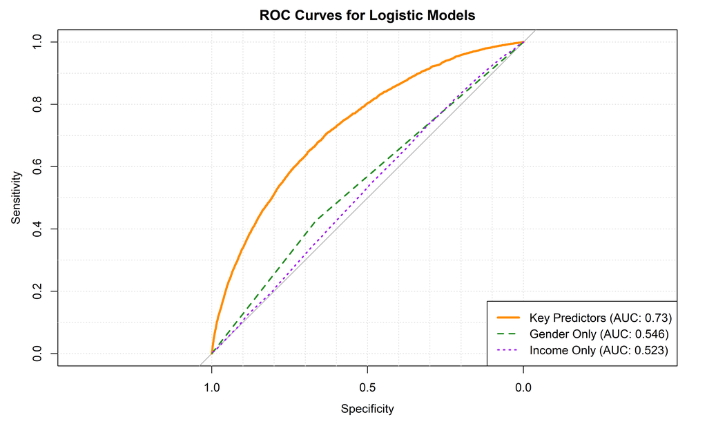

```r
# roc comparison plot
plot(res1$roc, col = col_line1, lwd = 3, main = "ROC Curves for Logistic Models", grid = TRUE)
plot(res2$roc, col = col_line2, add = TRUE, lwd = 2, lty = 2)
plot(res3$roc, col = col_line3, add = TRUE, lwd = 2, lty = 3)
legend("bottomright",
       legend = c(paste0("Key Predictors (AUC: ", round(res1$auc, 3), ")"),
                  paste0("Gender Only (AUC: ", round(res2$auc, 3), ")"),
                  paste0("Income Only (AUC: ", round(res3$auc, 3), ")")),
       col = c(col_line1, col_line2, col_line3),
       lwd = c(3, 2, 2), lty = c(1, 2, 3))
```

**Result:** The best logistic regression model achieved an **AUC of 0.73**. While strong for a linear model, the single-feature models (Gender, Income) performed near-chance (~0.50), confirming that demographics alone are insufficient.